# Part II - Factors Affecting Price of Fairly Used Vehicle in Nigeria

## IBRAHIM ALI

## Investigation Overview

> In this investigation, I wanted to look at the characteristics of vehicle that could be used to predict their prices. The main focus was on the four category features, vehicle engine cylinder, transmission type, fuel type and locally used or foriegn used vehicles

## Dataset Overview

> The data consisted of prices and attributes of approximately 1,451 observation. The attributes included the vehicle engine cylinder, transmission type, fuel type and locally used or foriegn used vehicles, year, location, car model, and odometer.

## Distribution of Vehicles Prices

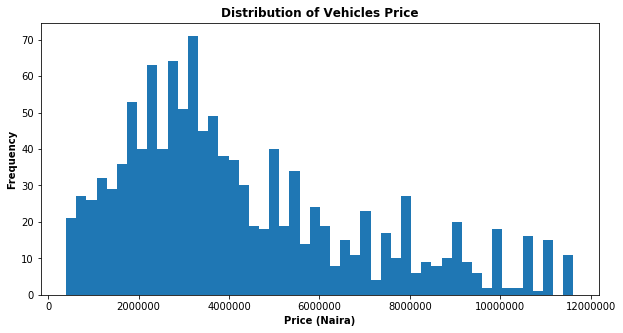

## Distribution of Vehicles Odometer

> The distribution of vehicles odometer has a long tailed distribution, most of the data are clustering around 0 to 300000km but there is an outlier on the data, when i remove the outlier distribution look roughly Bimodal shape!

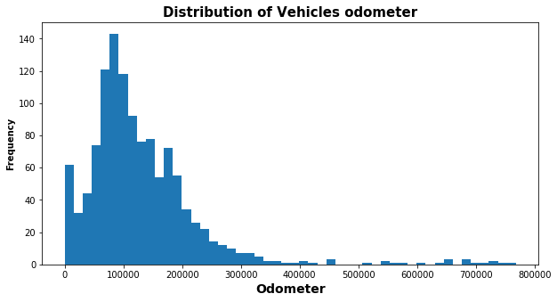

## Vehicles Price vs. Odometer Reading

I plot a scatter plot between vehicle selling price and odometer reading, Based on this graph it show a negative correlation between price and odometer, which show that vehicle with high odometer reading tend to have lower selling price while the one with lower odometer reading expected to be more expensive

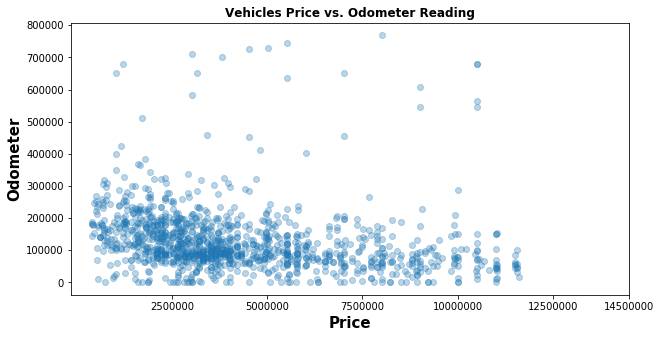

## Vehicles Price vs. Engine Cylinder Type

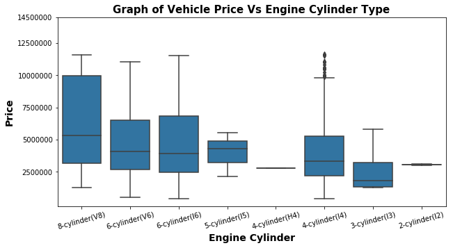

## Vehicles Price vs. Vehicle Fuel Type

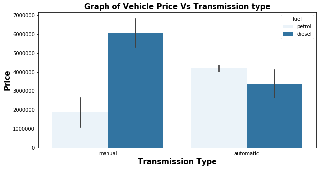

## Vehicles Price vs. Vehicle Fuel Type And Odometer Reading

Most of the vehicles in Nigeria using petrol as a fuel type, and the price of vehicle that used diesel as a fuel type tend to have poor correlation with odometer reading. That is means odometer reading does not have strong effect on the price of vehicle that used diesel as a fuel type.

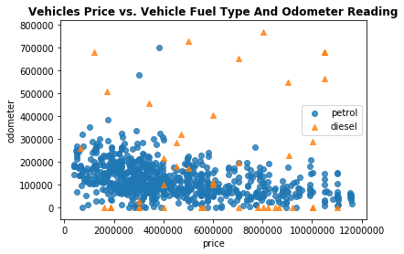